# Risk Factor Analysis

## Outcome Variable

**Outcome Variable:** ever_stunted

## Predictor Variables

**Intervention Variable:** enwast

**Adjustment Set:**

- arm
- W_mage
- meducyrs
- feducyrs
- vagbrth
- single
- brthmon
- W_parity
- delta_W_mage
- delta_meducyrs
- delta_feducyrs
- delta_vagbrth
- delta_single
- delta_brthmon
- delta_W_parity

## Stratifying Variables

The analysis was stratified on these variable(s):

- agecat
- studyid
- country

## Data Summary

| agecat | studyid | country | enwast | ever_stunted | n_cell | n |
| --- | --- | --- | --- | --- | --- | --- |
| 0-24 months (no birth st.) | CMC-V-BCS-2002 | INDIA | 0 | 0 | 22 | 296 |
| 0-24 months (no birth st.) | CMC-V-BCS-2002 | INDIA | 0 | 1 | 200 | 296 |
| 0-24 months (no birth st.) | CMC-V-BCS-2002 | INDIA | 1 | 0 | 6 | 296 |
| 0-24 months (no birth st.) | CMC-V-BCS-2002 | INDIA | 1 | 1 | 68 | 296 |
| 0-24 months (no birth st.) | CMIN | BANGLADESH | 0 | 0 | 35 | 168 |
| 0-24 months (no birth st.) | CMIN | BANGLADESH | 0 | 1 | 120 | 168 |
| 0-24 months (no birth st.) | CMIN | BANGLADESH | 1 | 0 | 6 | 168 |
| 0-24 months (no birth st.) | CMIN | BANGLADESH | 1 | 1 | 7 | 168 |
| 0-24 months (no birth st.) | COHORTS | GUATEMALA | 0 | 0 | 237 | 971 |
| 0-24 months (no birth st.) | COHORTS | GUATEMALA | 0 | 1 | 533 | 971 |
| 0-24 months (no birth st.) | COHORTS | GUATEMALA | 1 | 0 | 57 | 971 |
| 0-24 months (no birth st.) | COHORTS | GUATEMALA | 1 | 1 | 144 | 971 |
| 0-24 months (no birth st.) | COHORTS | INDIA | 0 | 0 | 3848 | 6492 |
| 0-24 months (no birth st.) | COHORTS | INDIA | 0 | 1 | 1481 | 6492 |
| 0-24 months (no birth st.) | COHORTS | INDIA | 1 | 0 | 816 | 6492 |
| 0-24 months (no birth st.) | COHORTS | INDIA | 1 | 1 | 347 | 6492 |
| 0-24 months (no birth st.) | COHORTS | PHILIPPINES | 0 | 0 | 787 | 2831 |
| 0-24 months (no birth st.) | COHORTS | PHILIPPINES | 0 | 1 | 1593 | 2831 |
| 0-24 months (no birth st.) | COHORTS | PHILIPPINES | 1 | 0 | 162 | 2831 |
| 0-24 months (no birth st.) | COHORTS | PHILIPPINES | 1 | 1 | 289 | 2831 |
| 0-24 months (no birth st.) | CONTENT | PERU | 0 | 0 | 161 | 195 |
| 0-24 months (no birth st.) | CONTENT | PERU | 0 | 1 | 33 | 195 |
| 0-24 months (no birth st.) | CONTENT | PERU | 1 | 0 | 1 | 195 |
| 0-24 months (no birth st.) | CONTENT | PERU | 1 | 1 | 0 | 195 |
| 0-24 months (no birth st.) | EE | PAKISTAN | 0 | 0 | 38 | 213 |
| 0-24 months (no birth st.) | EE | PAKISTAN | 0 | 1 | 144 | 213 |
| 0-24 months (no birth st.) | EE | PAKISTAN | 1 | 0 | 3 | 213 |
| 0-24 months (no birth st.) | EE | PAKISTAN | 1 | 1 | 28 | 213 |
| 0-24 months (no birth st.) | GMS-Nepal | NEPAL | 0 | 0 | 197 | 575 |
| 0-24 months (no birth st.) | GMS-Nepal | NEPAL | 0 | 1 | 254 | 575 |

[output cut: 338 more lines]

The following strata were considered:

- agecat: 0-24 months (no birth st.), studyid: CMC-V-BCS-2002, country: INDIA
- agecat: 0-24 months (no birth st.), studyid: CMIN, country: BANGLADESH
- agecat: 0-24 months (no birth st.), studyid: COHORTS, country: GUATEMALA
- agecat: 0-24 months (no birth st.), studyid: COHORTS, country: INDIA
- agecat: 0-24 months (no birth st.), studyid: COHORTS, country: PHILIPPINES
- agecat: 0-24 months (no birth st.), studyid: CONTENT, country: PERU
- agecat: 0-24 months (no birth st.), studyid: EE, country: PAKISTAN
- agecat: 0-24 months (no birth st.), studyid: GMS-Nepal, country: NEPAL
- agecat: 0-24 months (no birth st.), studyid: Guatemala BSC, country: GUATEMALA
- agecat: 0-24 months (no birth st.), studyid: iLiNS-Zinc, country: BURKINA FASO
- agecat: 0-24 months (no birth st.), studyid: IRC, country: INDIA
- agecat: 0-24 months (no birth st.), studyid: JiVitA-3, country: BANGLADESH
- agecat: 0-24 months (no birth st.), studyid: JiVitA-4, country: BANGLADESH
- agecat: 0-24 months (no birth st.), studyid: Keneba, country: GAMBIA
- agecat: 0-24 months (no birth st.), studyid: LCNI-5, country: MALAWI
- agecat: 0-24 months (no birth st.), studyid: MAL-ED, country: BANGLADESH
- agecat: 0-24 months (no birth st.), studyid: MAL-ED, country: BRAZIL
- agecat: 0-24 months (no birth st.), studyid: MAL-ED, country: INDIA
- agecat: 0-24 months (no birth st.), studyid: MAL-ED, country: NEPAL
- agecat: 0-24 months (no birth st.), studyid: MAL-ED, country: PERU
- agecat: 0-24 months (no birth st.), studyid: MAL-ED, country: SOUTH AFRICA
- agecat: 0-24 months (no birth st.), studyid: MAL-ED, country: TANZANIA, UNITED REPUBLIC OF
- agecat: 0-24 months (no birth st.), studyid: NIH-Birth, country: BANGLADESH
- agecat: 0-24 months (no birth st.), studyid: NIH-Crypto, country: BANGLADESH
- agecat: 0-24 months (no birth st.), studyid: PROBIT, country: BELARUS
- agecat: 0-24 months (no birth st.), studyid: PROVIDE, country: BANGLADESH
- agecat: 0-24 months (no birth st.), studyid: ResPak, country: PAKISTAN
- agecat: 0-24 months (no birth st.), studyid: SAS-CompFeed, country: INDIA
- agecat: 0-24 months (no birth st.), studyid: SAS-FoodSuppl, country: INDIA
- agecat: 0-24 months (no birth st.), studyid: TanzaniaChild2, country: TANZANIA, UNITED REPUBLIC OF
- agecat: 0-24 months (no birth st.), studyid: ZVITAMBO, country: ZIMBABWE
- agecat: 0-6 months (no birth st.), studyid: CMC-V-BCS-2002, country: INDIA
- agecat: 0-6 months (no birth st.), studyid: CMIN, country: BANGLADESH
- agecat: 0-6 months (no birth st.), studyid: COHORTS, country: GUATEMALA
- agecat: 0-6 months (no birth st.), studyid: COHORTS, country: INDIA
- agecat: 0-6 months (no birth st.), studyid: COHORTS, country: PHILIPPINES
- agecat: 0-6 months (no birth st.), studyid: CONTENT, country: PERU
- agecat: 0-6 months (no birth st.), studyid: EE, country: PAKISTAN
- agecat: 0-6 months (no birth st.), studyid: GMS-Nepal, country: NEPAL
- agecat: 0-6 months (no birth st.), studyid: Guatemala BSC, country: GUATEMALA
- agecat: 0-6 months (no birth st.), studyid: IRC, country: INDIA
- agecat: 0-6 months (no birth st.), studyid: JiVitA-3, country: BANGLADESH
- agecat: 0-6 months (no birth st.), studyid: JiVitA-4, country: BANGLADESH
- agecat: 0-6 months (no birth st.), studyid: Keneba, country: GAMBIA
- agecat: 0-6 months (no birth st.), studyid: LCNI-5, country: MALAWI
- agecat: 0-6 months (no birth st.), studyid: MAL-ED, country: BANGLADESH
- agecat: 0-6 months (no birth st.), studyid: MAL-ED, country: BRAZIL
- agecat: 0-6 months (no birth st.), studyid: MAL-ED, country: INDIA
- agecat: 0-6 months (no birth st.), studyid: MAL-ED, country: NEPAL
- agecat: 0-6 months (no birth st.), studyid: MAL-ED, country: PERU
- agecat: 0-6 months (no birth st.), studyid: MAL-ED, country: SOUTH AFRICA
- agecat: 0-6 months (no birth st.), studyid: MAL-ED, country: TANZANIA, UNITED REPUBLIC OF
- agecat: 0-6 months (no birth st.), studyid: NIH-Birth, country: BANGLADESH
- agecat: 0-6 months (no birth st.), studyid: NIH-Crypto, country: BANGLADESH
- agecat: 0-6 months (no birth st.), studyid: PROBIT, country: BELARUS
- agecat: 0-6 months (no birth st.), studyid: PROVIDE, country: BANGLADESH
- agecat: 0-6 months (no birth st.), studyid: ResPak, country: PAKISTAN
- agecat: 0-6 months (no birth st.), studyid: SAS-CompFeed, country: INDIA
- agecat: 0-6 months (no birth st.), studyid: SAS-FoodSuppl, country: INDIA
- agecat: 0-6 months (no birth st.), studyid: TanzaniaChild2, country: TANZANIA, UNITED REPUBLIC OF
- agecat: 0-6 months (no birth st.), studyid: ZVITAMBO, country: ZIMBABWE
- agecat: 6-24 months, studyid: CMC-V-BCS-2002, country: INDIA
- agecat: 6-24 months, studyid: CMIN, country: BANGLADESH
- agecat: 6-24 months, studyid: COHORTS, country: GUATEMALA
- agecat: 6-24 months, studyid: COHORTS, country: INDIA
- agecat: 6-24 months, studyid: COHORTS, country: PHILIPPINES
- agecat: 6-24 months, studyid: CONTENT, country: PERU
- agecat: 6-24 months, studyid: EE, country: PAKISTAN
- agecat: 6-24 months, studyid: GMS-Nepal, country: NEPAL
- agecat: 6-24 months, studyid: Guatemala BSC, country: GUATEMALA
- agecat: 6-24 months, studyid: iLiNS-Zinc, country: BURKINA FASO
- agecat: 6-24 months, studyid: IRC, country: INDIA
- agecat: 6-24 months, studyid: JiVitA-3, country: BANGLADESH
- agecat: 6-24 months, studyid: JiVitA-4, country: BANGLADESH
- agecat: 6-24 months, studyid: Keneba, country: GAMBIA
- agecat: 6-24 months, studyid: LCNI-5, country: MALAWI
- agecat: 6-24 months, studyid: MAL-ED, country: BANGLADESH
- agecat: 6-24 months, studyid: MAL-ED, country: BRAZIL
- agecat: 6-24 months, studyid: MAL-ED, country: INDIA
- agecat: 6-24 months, studyid: MAL-ED, country: NEPAL
- agecat: 6-24 months, studyid: MAL-ED, country: PERU
- agecat: 6-24 months, studyid: MAL-ED, country: SOUTH AFRICA
- agecat: 6-24 months, studyid: MAL-ED, country: TANZANIA, UNITED REPUBLIC OF
- agecat: 6-24 months, studyid: NIH-Birth, country: BANGLADESH
- agecat: 6-24 months, studyid: NIH-Crypto, country: BANGLADESH
- agecat: 6-24 months, studyid: PROBIT, country: BELARUS
- agecat: 6-24 months, studyid: PROVIDE, country: BANGLADESH
- agecat: 6-24 months, studyid: ResPak, country: PAKISTAN
- agecat: 6-24 months, studyid: SAS-CompFeed, country: INDIA
- agecat: 6-24 months, studyid: SAS-FoodSuppl, country: INDIA
- agecat: 6-24 months, studyid: TanzaniaChild2, country: TANZANIA, UNITED REPUBLIC OF
- agecat: 6-24 months, studyid: ZVITAMBO, country: ZIMBABWE

### Dropped Strata

Some strata were dropped due to rare outcomes:

- agecat: 0-24 months (no birth st.), studyid: CONTENT, country: PERU
- agecat: 0-24 months (no birth st.), studyid: EE, country: PAKISTAN
- agecat: 0-24 months (no birth st.), studyid: Guatemala BSC, country: GUATEMALA
- agecat: 0-24 months (no birth st.), studyid: LCNI-5, country: MALAWI
- agecat: 0-24 months (no birth st.), studyid: MAL-ED, country: BRAZIL
- agecat: 0-24 months (no birth st.), studyid: MAL-ED, country: PERU
- agecat: 0-24 months (no birth st.), studyid: MAL-ED, country: TANZANIA, UNITED REPUBLIC OF
- agecat: 0-6 months (no birth st.), studyid: CONTENT, country: PERU
- agecat: 0-6 months (no birth st.), studyid: Guatemala BSC, country: GUATEMALA
- agecat: 0-6 months (no birth st.), studyid: LCNI-5, country: MALAWI
- agecat: 0-6 months (no birth st.), studyid: MAL-ED, country: BRAZIL
- agecat: 0-6 months (no birth st.), studyid: MAL-ED, country: NEPAL
- agecat: 0-6 months (no birth st.), studyid: MAL-ED, country: PERU
- agecat: 0-6 months (no birth st.), studyid: MAL-ED, country: SOUTH AFRICA
- agecat: 0-6 months (no birth st.), studyid: MAL-ED, country: TANZANIA, UNITED REPUBLIC OF
- agecat: 0-6 months (no birth st.), studyid: SAS-FoodSuppl, country: INDIA
- agecat: 6-24 months, studyid: CMIN, country: BANGLADESH
- agecat: 6-24 months, studyid: CONTENT, country: PERU
- agecat: 6-24 months, studyid: EE, country: PAKISTAN
- agecat: 6-24 months, studyid: Guatemala BSC, country: GUATEMALA
- agecat: 6-24 months, studyid: LCNI-5, country: MALAWI
- agecat: 6-24 months, studyid: MAL-ED, country: BRAZIL
- agecat: 6-24 months, studyid: MAL-ED, country: PERU
- agecat: 6-24 months, studyid: MAL-ED, country: SOUTH AFRICA
- agecat: 6-24 months, studyid: MAL-ED, country: TANZANIA, UNITED REPUBLIC OF
- agecat: 6-24 months, studyid: ResPak, country: PAKISTAN

## Methods Detail

We’re interested in the causal parameters $E[Y_a]$ for all values of $a \in \mathcal{A}$. These parameters represent the mean outcome if, possibly contrary to fact, we intervened to set all units to have $A=a$. Under the randomization and positivity assumptions, these are identified by the statistical parameters $\psi_a=E_W[E_{Y|A,W}(Y|A=a,W)]$. In addition, we’re interested in the mean of $Y$, $E[Y]$ under no intervention (the observed mean). We will estimate these parameters by using SuperLearner to fit the relevant likelihood factors – $E_{Y|A,W}(Y|A=a,W)$ and $p(A=a|W)$, and then updating our likelihood fit using a joint TMLE.

For unadjusted analyses ($W=\{\}$), initial likelihoods were estimated using Lrnr_glm to estimate the simple $E(Y|A)$ and Lrnr_mean to estimate $p(A)$. For adjusted analyses, a small library containing Lrnr_glmnet, Lrnr_xgboost, and Lrnr_mean was used.

Having estimated these parameters, we will then use the delta method to estimate relative risks and attributable risks relative to a prespecified baseline level of $A$.

# Results Detail

## Results Plots

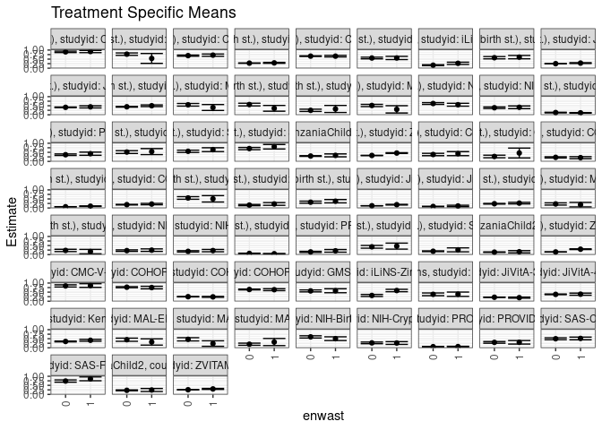

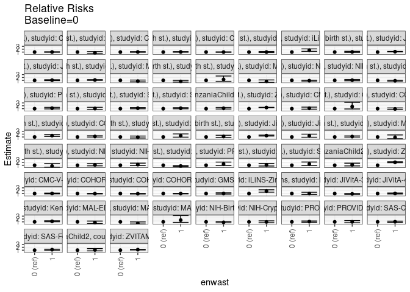

[figure not shown]

[figure not shown]

## Results Table

### Parameter: TSM

| agecat | studyid | country | intervention_level | baseline_level | estimate | ci_lower | ci_upper |
| --- | --- | --- | --- | --- | --- | --- | --- |
| 0-24 months (no birth st.) | CMC-V-BCS-2002 | INDIA | 0 | NA | 0.9009009 | 0.8615296 | 0.9402722 |
| 0-24 months (no birth st.) | CMC-V-BCS-2002 | INDIA | 1 | NA | 0.9189189 | 0.8566222 | 0.9812157 |
| 0-24 months (no birth st.) | CMIN | BANGLADESH | 0 | NA | 0.7741935 | 0.7081741 | 0.8402130 |
| 0-24 months (no birth st.) | CMIN | BANGLADESH | 1 | NA | 0.5384615 | 0.2666586 | 0.8102645 |
| 0-24 months (no birth st.) | COHORTS | GUATEMALA | 0 | NA | 0.6933163 | 0.6607283 | 0.7259044 |
| 0-24 months (no birth st.) | COHORTS | GUATEMALA | 1 | NA | 0.7194703 | 0.6570220 | 0.7819186 |
| 0-24 months (no birth st.) | COHORTS | INDIA | 0 | NA | 0.2789503 | 0.2669620 | 0.2909387 |
| 0-24 months (no birth st.) | COHORTS | INDIA | 1 | NA | 0.2933017 | 0.2675743 | 0.3190291 |
| 0-24 months (no birth st.) | COHORTS | PHILIPPINES | 0 | NA | 0.6648927 | 0.6460683 | 0.6837171 |
| 0-24 months (no birth st.) | COHORTS | PHILIPPINES | 1 | NA | 0.6637279 | 0.6207501 | 0.7067057 |
| 0-24 months (no birth st.) | GMS-Nepal | NEPAL | 0 | NA | 0.5610139 | 0.5151809 | 0.6068469 |
| 0-24 months (no birth st.) | GMS-Nepal | NEPAL | 1 | NA | 0.5637803 | 0.4753854 | 0.6521752 |
| 0-24 months (no birth st.) | iLiNS-Zinc | BURKINA FASO | 0 | NA | 0.1654815 | 0.1390760 | 0.1918869 |
| 0-24 months (no birth st.) | iLiNS-Zinc | BURKINA FASO | 1 | NA | 0.2692461 | 0.2089246 | 0.3295676 |
| 0-24 months (no birth st.) | IRC | INDIA | 0 | NA | 0.5774986 | 0.5154602 | 0.6395370 |
| 0-24 months (no birth st.) | IRC | INDIA | 1 | NA | 0.6102415 | 0.5187455 | 0.7017374 |
| 0-24 months (no birth st.) | JiVitA-3 | BANGLADESH | 0 | NA | 0.2486985 | 0.2407123 | 0.2566848 |
| 0-24 months (no birth st.) | JiVitA-3 | BANGLADESH | 1 | NA | 0.2817120 | 0.2598452 | 0.3035789 |
| 0-24 months (no birth st.) | JiVitA-4 | BANGLADESH | 0 | NA | 0.4116186 | 0.3926295 | 0.4306078 |
| 0-24 months (no birth st.) | JiVitA-4 | BANGLADESH | 1 | NA | 0.4385514 | 0.3793945 | 0.4977083 |
| 0-24 months (no birth st.) | Keneba | GAMBIA | 0 | NA | 0.4422882 | 0.4211508 | 0.4634256 |
| 0-24 months (no birth st.) | Keneba | GAMBIA | 1 | NA | 0.4999423 | 0.4551240 | 0.5447607 |
| 0-24 months (no birth st.) | MAL-ED | BANGLADESH | 0 | NA | 0.5518688 | 0.4787505 | 0.6249871 |
| 0-24 months (no birth st.) | MAL-ED | BANGLADESH | 1 | NA | 0.4020810 | 0.2389157 | 0.5652464 |
| 0-24 months (no birth st.) | MAL-ED | INDIA | 0 | NA | 0.5635338 | 0.4893135 | 0.6377541 |
| 0-24 months (no birth st.) | MAL-ED | INDIA | 1 | NA | 0.3568492 | 0.1982251 | 0.5154732 |
| 0-24 months (no birth st.) | MAL-ED | NEPAL | 0 | NA | 0.2456961 | 0.1831984 | 0.3081938 |
| 0-24 months (no birth st.) | MAL-ED | NEPAL | 1 | NA | 0.3216036 | 0.1280048 | 0.5152024 |
| 0-24 months (no birth st.) | MAL-ED | SOUTH AFRICA | 0 | NA | 0.5137255 | 0.4522679 | 0.5751831 |
| 0-24 months (no birth st.) | MAL-ED | SOUTH AFRICA | 1 | NA | 0.3000000 | 0.0987973 | 0.5012027 |

[output cut: 102 more lines]

### Parameter: E(Y)

| agecat | studyid | country | intervention_level | baseline_level | estimate | ci_lower | ci_upper |
| --- | --- | --- | --- | --- | --- | --- | --- |
| 0-24 months (no birth st.) | CMC-V-BCS-2002 | INDIA | NA | NA | 0.9054054 | 0.8720096 | 0.9388012 |
| 0-24 months (no birth st.) | CMIN | BANGLADESH | NA | NA | 0.7559524 | 0.6908084 | 0.8210964 |
| 0-24 months (no birth st.) | COHORTS | GUATEMALA | NA | NA | 0.6972194 | 0.6683052 | 0.7261335 |
| 0-24 months (no birth st.) | COHORTS | INDIA | NA | NA | 0.2815773 | 0.2706357 | 0.2925189 |
| 0-24 months (no birth st.) | COHORTS | PHILIPPINES | NA | NA | 0.6647828 | 0.6473904 | 0.6821751 |
| 0-24 months (no birth st.) | GMS-Nepal | NEPAL | NA | NA | 0.5634783 | 0.5229056 | 0.6040509 |
| 0-24 months (no birth st.) | iLiNS-Zinc | BURKINA FASO | NA | NA | 0.1780497 | 0.1518612 | 0.2042383 |
| 0-24 months (no birth st.) | IRC | INDIA | NA | NA | 0.5903955 | 0.5390958 | 0.6416952 |
| 0-24 months (no birth st.) | JiVitA-3 | BANGLADESH | NA | NA | 0.2522591 | 0.2445215 | 0.2599967 |
| 0-24 months (no birth st.) | JiVitA-4 | BANGLADESH | NA | NA | 0.4137487 | 0.3955533 | 0.4319441 |
| 0-24 months (no birth st.) | Keneba | GAMBIA | NA | NA | 0.4533437 | 0.4341009 | 0.4725865 |
| 0-24 months (no birth st.) | MAL-ED | BANGLADESH | NA | NA | 0.5253456 | 0.4587520 | 0.5919392 |
| 0-24 months (no birth st.) | MAL-ED | INDIA | NA | NA | 0.5285714 | 0.4608954 | 0.5962474 |
| 0-24 months (no birth st.) | MAL-ED | NEPAL | NA | NA | 0.2606635 | 0.2012891 | 0.3200380 |
| 0-24 months (no birth st.) | MAL-ED | SOUTH AFRICA | NA | NA | 0.4981818 | 0.4389793 | 0.5573843 |
| 0-24 months (no birth st.) | NIH-Birth | BANGLADESH | NA | NA | 0.6018868 | 0.5601729 | 0.6436007 |
| 0-24 months (no birth st.) | NIH-Crypto | BANGLADESH | NA | NA | 0.3935681 | 0.3560687 | 0.4310676 |
| 0-24 months (no birth st.) | PROBIT | BELARUS | NA | NA | 0.1205488 | 0.1047261 | 0.1363714 |
| 0-24 months (no birth st.) | PROVIDE | BANGLADESH | NA | NA | 0.3759874 | 0.3382238 | 0.4137509 |
| 0-24 months (no birth st.) | ResPak | PAKISTAN | NA | NA | 0.5198020 | 0.4507336 | 0.5888704 |
| 0-24 months (no birth st.) | SAS-CompFeed | INDIA | NA | NA | 0.5660550 | 0.5086421 | 0.6234680 |
| 0-24 months (no birth st.) | SAS-FoodSuppl | INDIA | NA | NA | 0.7198444 | 0.6648337 | 0.7748550 |
| 0-24 months (no birth st.) | TanzaniaChild2 | TANZANIA, UNITED REPUBLIC OF | NA | NA | 0.2984740 | 0.2794692 | 0.3174788 |
| 0-24 months (no birth st.) | ZVITAMBO | ZIMBABWE | NA | NA | 0.3491124 | 0.3407575 | 0.3574673 |
| 0-6 months (no birth st.) | CMC-V-BCS-2002 | INDIA | NA | NA | 0.3835616 | 0.3276935 | 0.4394298 |
| 0-6 months (no birth st.) | CMIN | BANGLADESH | NA | NA | 0.2857143 | 0.2171983 | 0.3542303 |
| 0-6 months (no birth st.) | COHORTS | GUATEMALA | NA | NA | 0.2195677 | 0.1921865 | 0.2469489 |
| 0-6 months (no birth st.) | COHORTS | INDIA | NA | NA | 0.0732095 | 0.0667753 | 0.0796436 |
| 0-6 months (no birth st.) | COHORTS | PHILIPPINES | NA | NA | 0.1889792 | 0.1745554 | 0.2034029 |
| 0-6 months (no birth st.) | EE | PAKISTAN | NA | NA | 0.5539906 | 0.4870787 | 0.6209025 |
| 0-6 months (no birth st.) | GMS-Nepal | NEPAL | NA | NA | 0.1739130 | 0.1429052 | 0.2049209 |
| 0-6 months (no birth st.) | IRC | INDIA | NA | NA | 0.3389831 | 0.2896025 | 0.3883636 |
| 0-6 months (no birth st.) | JiVitA-3 | BANGLADESH | NA | NA | 0.1303067 | 0.1247240 | 0.1358893 |
| 0-6 months (no birth st.) | JiVitA-4 | BANGLADESH | NA | NA | 0.0855893 | 0.0742297 | 0.0969489 |
| 0-6 months (no birth st.) | Keneba | GAMBIA | NA | NA | 0.2419720 | 0.2241162 | 0.2598277 |
| 0-6 months (no birth st.) | MAL-ED | BANGLADESH | NA | NA | 0.2165899 | 0.1616567 | 0.2715231 |
| 0-6 months (no birth st.) | MAL-ED | INDIA | NA | NA | 0.2190476 | 0.1629743 | 0.2751210 |
| 0-6 months (no birth st.) | NIH-Birth | BANGLADESH | NA | NA | 0.2283019 | 0.1925336 | 0.2640702 |
| 0-6 months (no birth st.) | NIH-Crypto | BANGLADESH | NA | NA | 0.1898928 | 0.1597870 | 0.2199986 |
| 0-6 months (no birth st.) | PROBIT | BELARUS | NA | NA | 0.0614448 | 0.0507274 | 0.0721623 |
| 0-6 months (no birth st.) | PROVIDE | BANGLADESH | NA | NA | 0.1595577 | 0.1310079 | 0.1881074 |
| 0-6 months (no birth st.) | ResPak | PAKISTAN | NA | NA | 0.4356436 | 0.3670959 | 0.5041912 |
| 0-6 months (no birth st.) | SAS-CompFeed | INDIA | NA | NA | 0.1928375 | 0.1691727 | 0.2165022 |
| 0-6 months (no birth st.) | TanzaniaChild2 | TANZANIA, UNITED REPUBLIC OF | NA | NA | 0.1368941 | 0.1226179 | 0.1511703 |
| 0-6 months (no birth st.) | ZVITAMBO | ZIMBABWE | NA | NA | 0.1720551 | 0.1654372 | 0.1786729 |
| 6-24 months | CMC-V-BCS-2002 | INDIA | NA | NA | 0.8478261 | 0.7957850 | 0.8998671 |
| 6-24 months | COHORTS | GUATEMALA | NA | NA | 0.7684332 | 0.7403543 | 0.7965121 |
| 6-24 months | COHORTS | INDIA | NA | NA | 0.2473250 | 0.2361242 | 0.2585258 |
| 6-24 months | COHORTS | PHILIPPINES | NA | NA | 0.6435738 | 0.6230503 | 0.6640973 |
| 6-24 months | GMS-Nepal | NEPAL | NA | NA | 0.5656566 | 0.5167753 | 0.6145378 |
| 6-24 months | iLiNS-Zinc | BURKINA FASO | NA | NA | 0.3623277 | 0.3130786 | 0.4115769 |
| 6-24 months | IRC | INDIA | NA | NA | 0.3803419 | 0.3180067 | 0.4426771 |
| 6-24 months | JiVitA-3 | BANGLADESH | NA | NA | 0.2157031 | 0.2063258 | 0.2250804 |
| 6-24 months | JiVitA-4 | BANGLADESH | NA | NA | 0.3776070 | 0.3590122 | 0.3962019 |
| 6-24 months | Keneba | GAMBIA | NA | NA | 0.3601801 | 0.3391307 | 0.3812295 |
| 6-24 months | MAL-ED | BANGLADESH | NA | NA | 0.4240506 | 0.3467471 | 0.5013542 |
| 6-24 months | MAL-ED | INDIA | NA | NA | 0.4220779 | 0.3438191 | 0.5003367 |
| 6-24 months | MAL-ED | NEPAL | NA | NA | 0.2113402 | 0.1537425 | 0.2689379 |
| 6-24 months | NIH-Birth | BANGLADESH | NA | NA | 0.5739130 | 0.5216565 | 0.6261696 |
| 6-24 months | NIH-Crypto | BANGLADESH | NA | NA | 0.2628459 | 0.2244546 | 0.3012371 |
| 6-24 months | PROBIT | BELARUS | NA | NA | 0.0642659 | 0.0526827 | 0.0758490 |
| 6-24 months | PROVIDE | BANGLADESH | NA | NA | 0.3004386 | 0.2583143 | 0.3425629 |
| 6-24 months | SAS-CompFeed | INDIA | NA | NA | 0.5030750 | 0.4588491 | 0.5473009 |
| 6-24 months | SAS-FoodSuppl | INDIA | NA | NA | 0.7572016 | 0.7031798 | 0.8112234 |
| 6-24 months | TanzaniaChild2 | TANZANIA, UNITED REPUBLIC OF | NA | NA | 0.2255639 | 0.2050525 | 0.2460753 |
| 6-24 months | ZVITAMBO | ZIMBABWE | NA | NA | 0.2634638 | 0.2540597 | 0.2728679 |

### Parameter: RR

| agecat | studyid | country | intervention_level | baseline_level | estimate | ci_lower | ci_upper |
| --- | --- | --- | --- | --- | --- | --- | --- |
| 0-24 months (no birth st.) | CMC-V-BCS-2002 | INDIA | 0 | 0 | 1.0000000 | 1.0000000 | 1.0000000 |
| 0-24 months (no birth st.) | CMC-V-BCS-2002 | INDIA | 1 | 0 | 1.0200000 | 0.9409586 | 1.1056810 |
| 0-24 months (no birth st.) | CMIN | BANGLADESH | 0 | 0 | 1.0000000 | 1.0000000 | 1.0000000 |
| 0-24 months (no birth st.) | CMIN | BANGLADESH | 1 | 0 | 0.6955128 | 0.4168474 | 1.1604680 |
| 0-24 months (no birth st.) | COHORTS | GUATEMALA | 0 | 0 | 1.0000000 | 1.0000000 | 1.0000000 |
| 0-24 months (no birth st.) | COHORTS | GUATEMALA | 1 | 0 | 1.0377230 | 0.9402960 | 1.1452448 |
| 0-24 months (no birth st.) | COHORTS | INDIA | 0 | 0 | 1.0000000 | 1.0000000 | 1.0000000 |
| 0-24 months (no birth st.) | COHORTS | INDIA | 1 | 0 | 1.0514476 | 0.9543826 | 1.1583845 |
| 0-24 months (no birth st.) | COHORTS | PHILIPPINES | 0 | 0 | 1.0000000 | 1.0000000 | 1.0000000 |
| 0-24 months (no birth st.) | COHORTS | PHILIPPINES | 1 | 0 | 0.9982481 | 0.9307921 | 1.0705928 |
| 0-24 months (no birth st.) | GMS-Nepal | NEPAL | 0 | 0 | 1.0000000 | 1.0000000 | 1.0000000 |
| 0-24 months (no birth st.) | GMS-Nepal | NEPAL | 1 | 0 | 1.0049311 | 0.8421524 | 1.1991732 |
| 0-24 months (no birth st.) | iLiNS-Zinc | BURKINA FASO | 0 | 0 | 1.0000000 | 1.0000000 | 1.0000000 |
| 0-24 months (no birth st.) | iLiNS-Zinc | BURKINA FASO | 1 | 0 | 1.6270467 | 1.2559921 | 2.1077211 |
| 0-24 months (no birth st.) | IRC | INDIA | 0 | 0 | 1.0000000 | 1.0000000 | 1.0000000 |
| 0-24 months (no birth st.) | IRC | INDIA | 1 | 0 | 1.0566977 | 0.8787904 | 1.2706215 |
| 0-24 months (no birth st.) | JiVitA-3 | BANGLADESH | 0 | 0 | 1.0000000 | 1.0000000 | 1.0000000 |
| 0-24 months (no birth st.) | JiVitA-3 | BANGLADESH | 1 | 0 | 1.1327450 | 1.0449357 | 1.2279332 |
| 0-24 months (no birth st.) | JiVitA-4 | BANGLADESH | 0 | 0 | 1.0000000 | 1.0000000 | 1.0000000 |
| 0-24 months (no birth st.) | JiVitA-4 | BANGLADESH | 1 | 0 | 1.0654313 | 0.9250043 | 1.2271769 |
| 0-24 months (no birth st.) | Keneba | GAMBIA | 0 | 0 | 1.0000000 | 1.0000000 | 1.0000000 |
| 0-24 months (no birth st.) | Keneba | GAMBIA | 1 | 0 | 1.1303542 | 1.0222313 | 1.2499136 |
| 0-24 months (no birth st.) | MAL-ED | BANGLADESH | 0 | 0 | 1.0000000 | 1.0000000 | 1.0000000 |
| 0-24 months (no birth st.) | MAL-ED | BANGLADESH | 1 | 0 | 0.7285809 | 0.4756961 | 1.1159017 |
| 0-24 months (no birth st.) | MAL-ED | INDIA | 0 | 0 | 1.0000000 | 1.0000000 | 1.0000000 |
| 0-24 months (no birth st.) | MAL-ED | INDIA | 1 | 0 | 0.6332347 | 0.3983436 | 1.0066338 |
| 0-24 months (no birth st.) | MAL-ED | NEPAL | 0 | 0 | 1.0000000 | 1.0000000 | 1.0000000 |
| 0-24 months (no birth st.) | MAL-ED | NEPAL | 1 | 0 | 1.3089489 | 0.6806719 | 2.5171408 |
| 0-24 months (no birth st.) | MAL-ED | SOUTH AFRICA | 0 | 0 | 1.0000000 | 1.0000000 | 1.0000000 |
| 0-24 months (no birth st.) | MAL-ED | SOUTH AFRICA | 1 | 0 | 0.5839695 | 0.2954758 | 1.1541396 |

[output cut: 102 more lines]

### Parameter: PAR

| agecat | studyid | country | intervention_level | baseline_level | estimate | ci_lower | ci_upper |
| --- | --- | --- | --- | --- | --- | --- | --- |
| 0-24 months (no birth st.) | CMC-V-BCS-2002 | INDIA | 0 | NA | 0.0045045 | -0.0139408 | 0.0229498 |
| 0-24 months (no birth st.) | CMIN | BANGLADESH | 0 | NA | -0.0182412 | -0.0418995 | 0.0054172 |
| 0-24 months (no birth st.) | COHORTS | GUATEMALA | 0 | NA | 0.0039030 | -0.0106623 | 0.0184684 |
| 0-24 months (no birth st.) | COHORTS | INDIA | 0 | NA | 0.0026270 | -0.0024189 | 0.0076728 |
| 0-24 months (no birth st.) | COHORTS | PHILIPPINES | 0 | NA | -0.0001099 | -0.0075205 | 0.0073006 |
| 0-24 months (no birth st.) | GMS-Nepal | NEPAL | 0 | NA | 0.0024644 | -0.0187617 | 0.0236904 |
| 0-24 months (no birth st.) | iLiNS-Zinc | BURKINA FASO | 0 | NA | 0.0125683 | 0.0050932 | 0.0200434 |
| 0-24 months (no birth st.) | IRC | INDIA | 0 | NA | 0.0128969 | -0.0218755 | 0.0476692 |
| 0-24 months (no birth st.) | JiVitA-3 | BANGLADESH | 0 | NA | 0.0035606 | 0.0010330 | 0.0060881 |
| 0-24 months (no birth st.) | JiVitA-4 | BANGLADESH | 0 | NA | 0.0021301 | -0.0030355 | 0.0072956 |
| 0-24 months (no birth st.) | Keneba | GAMBIA | 0 | NA | 0.0110555 | 0.0020864 | 0.0200247 |
| 0-24 months (no birth st.) | MAL-ED | BANGLADESH | 0 | NA | -0.0265232 | -0.0578642 | 0.0048179 |
| 0-24 months (no birth st.) | MAL-ED | INDIA | 0 | NA | -0.0349624 | -0.0664696 | -0.0034552 |
| 0-24 months (no birth st.) | MAL-ED | NEPAL | 0 | NA | 0.0149674 | -0.0110320 | 0.0409668 |
| 0-24 months (no birth st.) | MAL-ED | SOUTH AFRICA | 0 | NA | -0.0155437 | -0.0321956 | 0.0011083 |
| 0-24 months (no birth st.) | NIH-Birth | BANGLADESH | 0 | NA | -0.0193514 | -0.0465781 | 0.0078752 |
| 0-24 months (no birth st.) | NIH-Crypto | BANGLADESH | 0 | NA | 0.0036727 | -0.0181993 | 0.0255447 |
| 0-24 months (no birth st.) | PROBIT | BELARUS | 0 | NA | -0.0022458 | -0.0059563 | 0.0014647 |
| 0-24 months (no birth st.) | PROVIDE | BANGLADESH | 0 | NA | 0.0086306 | -0.0110695 | 0.0283307 |
| 0-24 months (no birth st.) | ResPak | PAKISTAN | 0 | NA | 0.0045997 | -0.0295638 | 0.0387633 |
| 0-24 months (no birth st.) | SAS-CompFeed | INDIA | 0 | NA | 0.0087867 | -0.0043127 | 0.0218860 |
| 0-24 months (no birth st.) | SAS-FoodSuppl | INDIA | 0 | NA | 0.0123429 | -0.0120813 | 0.0367670 |
| 0-24 months (no birth st.) | TanzaniaChild2 | TANZANIA, UNITED REPUBLIC OF | 0 | NA | 0.0018985 | -0.0030411 | 0.0068380 |
| 0-24 months (no birth st.) | ZVITAMBO | ZIMBABWE | 0 | NA | 0.0221818 | 0.0181412 | 0.0262225 |
| 0-6 months (no birth st.) | CMC-V-BCS-2002 | INDIA | 0 | NA | 0.0041486 | -0.0290858 | 0.0373830 |
| 0-6 months (no birth st.) | CMIN | BANGLADESH | 0 | NA | 0.0147465 | -0.0083076 | 0.0378007 |
| 0-6 months (no birth st.) | COHORTS | GUATEMALA | 0 | NA | -0.0039599 | -0.0185563 | 0.0106365 |
| 0-6 months (no birth st.) | COHORTS | INDIA | 0 | NA | 0.0059822 | 0.0025729 | 0.0093914 |
| 0-6 months (no birth st.) | COHORTS | PHILIPPINES | 0 | NA | 0.0044183 | -0.0020132 | 0.0108497 |
| 0-6 months (no birth st.) | EE | PAKISTAN | 0 | NA | 0.0008057 | -0.0268683 | 0.0284797 |
| 0-6 months (no birth st.) | GMS-Nepal | NEPAL | 0 | NA | 0.0132059 | -0.0042453 | 0.0306572 |
| 0-6 months (no birth st.) | IRC | INDIA | 0 | NA | 0.0194101 | -0.0145359 | 0.0533561 |
| 0-6 months (no birth st.) | JiVitA-3 | BANGLADESH | 0 | NA | 0.0063795 | 0.0042370 | 0.0085220 |
| 0-6 months (no birth st.) | JiVitA-4 | BANGLADESH | 0 | NA | 0.0025652 | -0.0010067 | 0.0061372 |
| 0-6 months (no birth st.) | Keneba | GAMBIA | 0 | NA | 0.0067311 | -0.0023427 | 0.0158049 |
| 0-6 months (no birth st.) | MAL-ED | BANGLADESH | 0 | NA | -0.0068738 | -0.0310957 | 0.0173481 |
| 0-6 months (no birth st.) | MAL-ED | INDIA | 0 | NA | -0.0108374 | -0.0345750 | 0.0129001 |
| 0-6 months (no birth st.) | NIH-Birth | BANGLADESH | 0 | NA | 0.0079447 | -0.0155458 | 0.0314351 |
| 0-6 months (no birth st.) | NIH-Crypto | BANGLADESH | 0 | NA | 0.0103911 | -0.0081098 | 0.0288919 |
| 0-6 months (no birth st.) | PROBIT | BELARUS | 0 | NA | -0.0041468 | -0.0072825 | -0.0010111 |
| 0-6 months (no birth st.) | PROVIDE | BANGLADESH | 0 | NA | 0.0121821 | -0.0036483 | 0.0280125 |
| 0-6 months (no birth st.) | ResPak | PAKISTAN | 0 | NA | 0.0063068 | -0.0276277 | 0.0402412 |
| 0-6 months (no birth st.) | SAS-CompFeed | INDIA | 0 | NA | 0.0083425 | -0.0029741 | 0.0196592 |
| 0-6 months (no birth st.) | TanzaniaChild2 | TANZANIA, UNITED REPUBLIC OF | 0 | NA | 0.0013661 | -0.0024502 | 0.0051824 |
| 0-6 months (no birth st.) | ZVITAMBO | ZIMBABWE | 0 | NA | 0.0259781 | 0.0223228 | 0.0296334 |
| 6-24 months | CMC-V-BCS-2002 | INDIA | 0 | NA | 0.0049689 | -0.0233466 | 0.0332845 |
| 6-24 months | COHORTS | GUATEMALA | 0 | NA | -0.0032919 | -0.0161850 | 0.0096012 |
| 6-24 months | COHORTS | INDIA | 0 | NA | -0.0018965 | -0.0068471 | 0.0030541 |
| 6-24 months | COHORTS | PHILIPPINES | 0 | NA | -0.0015653 | -0.0101653 | 0.0070347 |
| 6-24 months | GMS-Nepal | NEPAL | 0 | NA | -0.0011696 | -0.0253700 | 0.0230308 |
| 6-24 months | iLiNS-Zinc | BURKINA FASO | 0 | NA | 0.0458634 | 0.0293662 | 0.0623605 |
| 6-24 months | IRC | INDIA | 0 | NA | 0.0017208 | -0.0386247 | 0.0420663 |
| 6-24 months | JiVitA-3 | BANGLADESH | 0 | NA | -0.0021217 | -0.0049970 | 0.0007535 |
| 6-24 months | JiVitA-4 | BANGLADESH | 0 | NA | 0.0008083 | -0.0042474 | 0.0058641 |
| 6-24 months | Keneba | GAMBIA | 0 | NA | 0.0111008 | 0.0011957 | 0.0210058 |
| 6-24 months | MAL-ED | BANGLADESH | 0 | NA | -0.0221032 | -0.0572034 | 0.0129970 |
| 6-24 months | MAL-ED | INDIA | 0 | NA | -0.0456640 | -0.0828925 | -0.0084355 |
| 6-24 months | MAL-ED | NEPAL | 0 | NA | 0.0136658 | -0.0100938 | 0.0374254 |
| 6-24 months | NIH-Birth | BANGLADESH | 0 | NA | -0.0280263 | -0.0608087 | 0.0047561 |
| 6-24 months | NIH-Crypto | BANGLADESH | 0 | NA | -0.0081132 | -0.0301244 | 0.0138979 |
| 6-24 months | PROBIT | BELARUS | 0 | NA | 0.0017675 | -0.0010854 | 0.0046204 |
| 6-24 months | PROVIDE | BANGLADESH | 0 | NA | 0.0012767 | -0.0193164 | 0.0218697 |
| 6-24 months | SAS-CompFeed | INDIA | 0 | NA | 0.0031514 | -0.0076257 | 0.0139285 |
| 6-24 months | SAS-FoodSuppl | INDIA | 0 | NA | 0.0208832 | -0.0010346 | 0.0428011 |
| 6-24 months | TanzaniaChild2 | TANZANIA, UNITED REPUBLIC OF | 0 | NA | 0.0005201 | -0.0047989 | 0.0058391 |
| 6-24 months | ZVITAMBO | ZIMBABWE | 0 | NA | 0.0059827 | 0.0021247 | 0.0098406 |

### Parameter: PAF

| agecat | studyid | country | intervention_level | baseline_level | estimate | ci_lower | ci_upper |
| --- | --- | --- | --- | --- | --- | --- | --- |
| 0-24 months (no birth st.) | CMC-V-BCS-2002 | INDIA | 0 | NA | 0.0049751 | -0.0156225 | 0.0251550 |
| 0-24 months (no birth st.) | CMIN | BANGLADESH | 0 | NA | -0.0241300 | -0.0562877 | 0.0070486 |
| 0-24 months (no birth st.) | COHORTS | GUATEMALA | 0 | NA | 0.0055980 | -0.0155188 | 0.0262757 |
| 0-24 months (no birth st.) | COHORTS | INDIA | 0 | NA | 0.0093295 | -0.0087523 | 0.0270872 |
| 0-24 months (no birth st.) | COHORTS | PHILIPPINES | 0 | NA | -0.0001654 | -0.0113752 | 0.0109201 |
| 0-24 months (no birth st.) | GMS-Nepal | NEPAL | 0 | NA | 0.0043735 | -0.0340200 | 0.0413414 |
| 0-24 months (no birth st.) | iLiNS-Zinc | BURKINA FASO | 0 | NA | 0.0705885 | 0.0275334 | 0.1117373 |
| 0-24 months (no birth st.) | IRC | INDIA | 0 | NA | 0.0218444 | -0.0388986 | 0.0790359 |
| 0-24 months (no birth st.) | JiVitA-3 | BANGLADESH | 0 | NA | 0.0141148 | 0.0040623 | 0.0240657 |
| 0-24 months (no birth st.) | JiVitA-4 | BANGLADESH | 0 | NA | 0.0051482 | -0.0074207 | 0.0175603 |
| 0-24 months (no birth st.) | Keneba | GAMBIA | 0 | NA | 0.0243866 | 0.0043846 | 0.0439868 |
| 0-24 months (no birth st.) | MAL-ED | BANGLADESH | 0 | NA | -0.0504871 | -0.1123479 | 0.0079335 |
| 0-24 months (no birth st.) | MAL-ED | INDIA | 0 | NA | -0.0661451 | -0.1282175 | -0.0074877 |
| 0-24 months (no birth st.) | MAL-ED | NEPAL | 0 | NA | 0.0574204 | -0.0473529 | 0.1517126 |
| 0-24 months (no birth st.) | MAL-ED | SOUTH AFRICA | 0 | NA | -0.0312008 | -0.0653957 | 0.0018966 |
| 0-24 months (no birth st.) | NIH-Birth | BANGLADESH | 0 | NA | -0.0321513 | -0.0785183 | 0.0122224 |
| 0-24 months (no birth st.) | NIH-Crypto | BANGLADESH | 0 | NA | 0.0093318 | -0.0478428 | 0.0633866 |
| 0-24 months (no birth st.) | PROBIT | BELARUS | 0 | NA | -0.0186298 | -0.0488171 | 0.0106886 |
| 0-24 months (no birth st.) | PROVIDE | BANGLADESH | 0 | NA | 0.0229545 | -0.0308634 | 0.0739626 |
| 0-24 months (no birth st.) | ResPak | PAKISTAN | 0 | NA | 0.0088490 | -0.0591164 | 0.0724530 |
| 0-24 months (no birth st.) | SAS-CompFeed | INDIA | 0 | NA | 0.0155226 | -0.0084223 | 0.0388990 |
| 0-24 months (no birth st.) | SAS-FoodSuppl | INDIA | 0 | NA | 0.0171466 | -0.0174973 | 0.0506110 |
| 0-24 months (no birth st.) | TanzaniaChild2 | TANZANIA, UNITED REPUBLIC OF | 0 | NA | 0.0063606 | -0.0103266 | 0.0227722 |
| 0-24 months (no birth st.) | ZVITAMBO | ZIMBABWE | 0 | NA | 0.0635378 | 0.0518911 | 0.0750414 |
| 0-6 months (no birth st.) | CMC-V-BCS-2002 | INDIA | 0 | NA | 0.0108160 | -0.0797286 | 0.0937676 |
| 0-6 months (no birth st.) | CMIN | BANGLADESH | 0 | NA | 0.0516129 | -0.0323589 | 0.1287544 |
| 0-6 months (no birth st.) | COHORTS | GUATEMALA | 0 | NA | -0.0180351 | -0.0867148 | 0.0463040 |
| 0-6 months (no birth st.) | COHORTS | INDIA | 0 | NA | 0.0817132 | 0.0344497 | 0.1266632 |
| 0-6 months (no birth st.) | COHORTS | PHILIPPINES | 0 | NA | 0.0233798 | -0.0112444 | 0.0568184 |
| 0-6 months (no birth st.) | EE | PAKISTAN | 0 | NA | 0.0014544 | -0.0497709 | 0.0501800 |
| 0-6 months (no birth st.) | GMS-Nepal | NEPAL | 0 | NA | 0.0759341 | -0.0295275 | 0.1705925 |
| 0-6 months (no birth st.) | IRC | INDIA | 0 | NA | 0.0572597 | -0.0483729 | 0.1522490 |
| 0-6 months (no birth st.) | JiVitA-3 | BANGLADESH | 0 | NA | 0.0489574 | 0.0325894 | 0.0650484 |
| 0-6 months (no birth st.) | JiVitA-4 | BANGLADESH | 0 | NA | 0.0299716 | -0.0127350 | 0.0708773 |
| 0-6 months (no birth st.) | Keneba | GAMBIA | 0 | NA | 0.0278176 | -0.0104029 | 0.0645924 |
| 0-6 months (no birth st.) | MAL-ED | BANGLADESH | 0 | NA | -0.0317366 | -0.1497168 | 0.0741368 |
| 0-6 months (no birth st.) | MAL-ED | INDIA | 0 | NA | -0.0494753 | -0.1632968 | 0.0532096 |
| 0-6 months (no birth st.) | NIH-Birth | BANGLADESH | 0 | NA | 0.0347989 | -0.0736715 | 0.1323108 |
| 0-6 months (no birth st.) | NIH-Crypto | BANGLADESH | 0 | NA | 0.0547208 | -0.0476547 | 0.1470922 |
| 0-6 months (no birth st.) | PROBIT | BELARUS | 0 | NA | -0.0674884 | -0.1161474 | -0.0209508 |
| 0-6 months (no birth st.) | PROVIDE | BANGLADESH | 0 | NA | 0.0763493 | -0.0276904 | 0.1698564 |
| 0-6 months (no birth st.) | ResPak | PAKISTAN | 0 | NA | 0.0144769 | -0.0665975 | 0.0893886 |
| 0-6 months (no birth st.) | SAS-CompFeed | INDIA | 0 | NA | 0.0432620 | -0.0152657 | 0.0984157 |
| 0-6 months (no birth st.) | TanzaniaChild2 | TANZANIA, UNITED REPUBLIC OF | 0 | NA | 0.0099791 | -0.0182828 | 0.0374567 |
| 0-6 months (no birth st.) | ZVITAMBO | ZIMBABWE | 0 | NA | 0.1509872 | 0.1300058 | 0.1714626 |
| 6-24 months | CMC-V-BCS-2002 | INDIA | 0 | NA | 0.0058608 | -0.0281245 | 0.0387227 |
| 6-24 months | COHORTS | GUATEMALA | 0 | NA | -0.0042839 | -0.0212071 | 0.0123589 |
| 6-24 months | COHORTS | INDIA | 0 | NA | -0.0076679 | -0.0278841 | 0.0121507 |
| 6-24 months | COHORTS | PHILIPPINES | 0 | NA | -0.0024322 | -0.0158860 | 0.0108434 |
| 6-24 months | GMS-Nepal | NEPAL | 0 | NA | -0.0020677 | -0.0457766 | 0.0398144 |
| 6-24 months | iLiNS-Zinc | BURKINA FASO | 0 | NA | 0.1265799 | 0.0708077 | 0.1790045 |
| 6-24 months | IRC | INDIA | 0 | NA | 0.0045244 | -0.1074113 | 0.1051457 |
| 6-24 months | JiVitA-3 | BANGLADESH | 0 | NA | -0.0098363 | -0.0232689 | 0.0034200 |
| 6-24 months | JiVitA-4 | BANGLADESH | 0 | NA | 0.0021406 | -0.0113432 | 0.0154447 |
| 6-24 months | Keneba | GAMBIA | 0 | NA | 0.0308201 | 0.0029286 | 0.0579313 |
| 6-24 months | MAL-ED | BANGLADESH | 0 | NA | -0.0521240 | -0.1385643 | 0.0277538 |
| 6-24 months | MAL-ED | INDIA | 0 | NA | -0.1081886 | -0.2015137 | -0.0221123 |
| 6-24 months | MAL-ED | NEPAL | 0 | NA | 0.0646625 | -0.0540176 | 0.1699795 |
| 6-24 months | NIH-Birth | BANGLADESH | 0 | NA | -0.0488337 | -0.1078831 | 0.0070684 |
| 6-24 months | NIH-Crypto | BANGLADESH | 0 | NA | -0.0308668 | -0.1180012 | 0.0494765 |
| 6-24 months | PROBIT | BELARUS | 0 | NA | 0.0275034 | -0.0183336 | 0.0712772 |
| 6-24 months | PROVIDE | BANGLADESH | 0 | NA | 0.0042494 | -0.0667110 | 0.0704894 |
| 6-24 months | SAS-CompFeed | INDIA | 0 | NA | 0.0062642 | -0.0156965 | 0.0277502 |
| 6-24 months | SAS-FoodSuppl | INDIA | 0 | NA | 0.0275795 | -0.0021485 | 0.0564256 |
| 6-24 months | TanzaniaChild2 | TANZANIA, UNITED REPUBLIC OF | 0 | NA | 0.0023058 | -0.0215560 | 0.0256102 |
| 6-24 months | ZVITAMBO | ZIMBABWE | 0 | NA | 0.0227077 | 0.0079608 | 0.0372354 |